# Transfer label microenvironment cells (102, CD4 T)

Ramon Massoni-Badosa

mayo 2022

# 1 Introduction

In this notebook we will transfer the label and UMAP coordinates from the CD4 T cells of the tonsil atlas to the CD4 T cells of the MCL sample (case 102) using SLOcatoR.

# 2 Pre-processing

## 2.1 Load packages

```r
library(Seurat)
library(Signac)
library(SLOcatoR)
library(EnsDb.Hsapiens.v86)
library(ggpubr)
library(tidyverse)
library(pals)
library(here)
set.seed(173)
```

## 2.2 Define paths and parameters

```r
# Paths
path_to_query <-  here("MCL/results/R_objects/6.seurat_microenvironment_102.rds")
path_to_save1 <- here("MCL/results/R_objects/7.merged_CD4_T_reference_query_102.rds")
path_to_save2 <- here("MCL/results/R_objects/7.seurat_CD4_T_102_annotated.rds")


# Misc
label_var <- "annotation_paper"
batch_var <- "assay"


# Source key functions and variables
source(here("scRNA-seq/bin/utils_final_clusters.R"))
source(here("scRNA-seq/bin/utils_figure2.R"))
```

## 2.3 Read data

```r
reference <- readRDS(path_to_save_cd4)
reference$annotation_paper <- factor(
  reference$annotation_20220215,
  levels = names(colors_rna)
)
query <- readRDS(path_to_query)
```

Since here we will focus on the RNA, let us remove the ATAC assay:

```r
# query[["ATAC"]] <- NULL
```

# 3 Transfer labels and UMAP coords

## 3.1 Subset query to keep only CD4 T cells

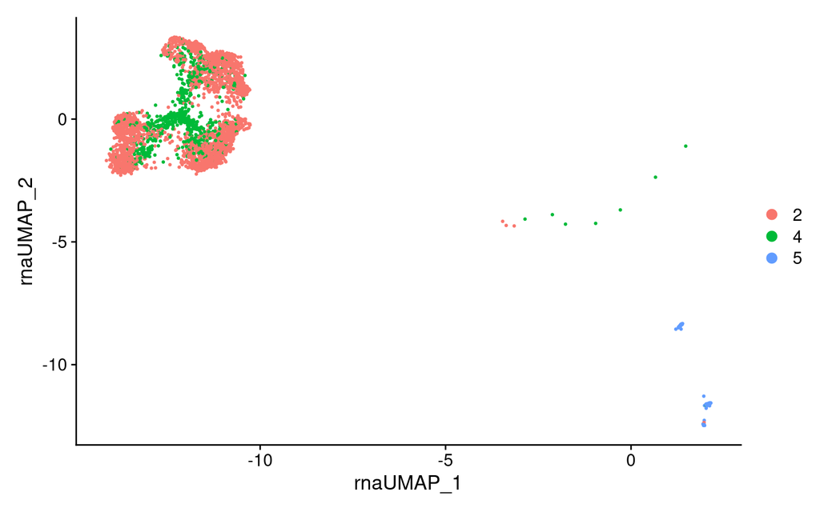

```r
DimPlot(query)
```

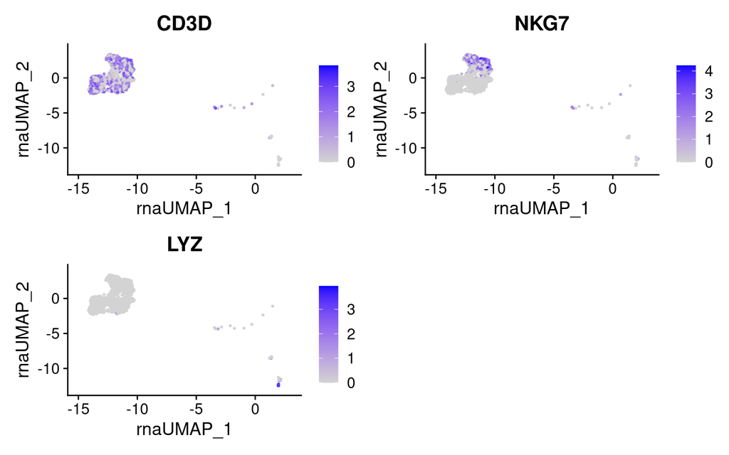

```r
FeaturePlot(query, c("CD3D", "NKG7", "LYZ"))
```

Cluster 5 is cleary myeloid and other non-lymphoid cells (CD3-LYZ+). Thus, let us subset to keep only clusters 2 and 4 and recluster:

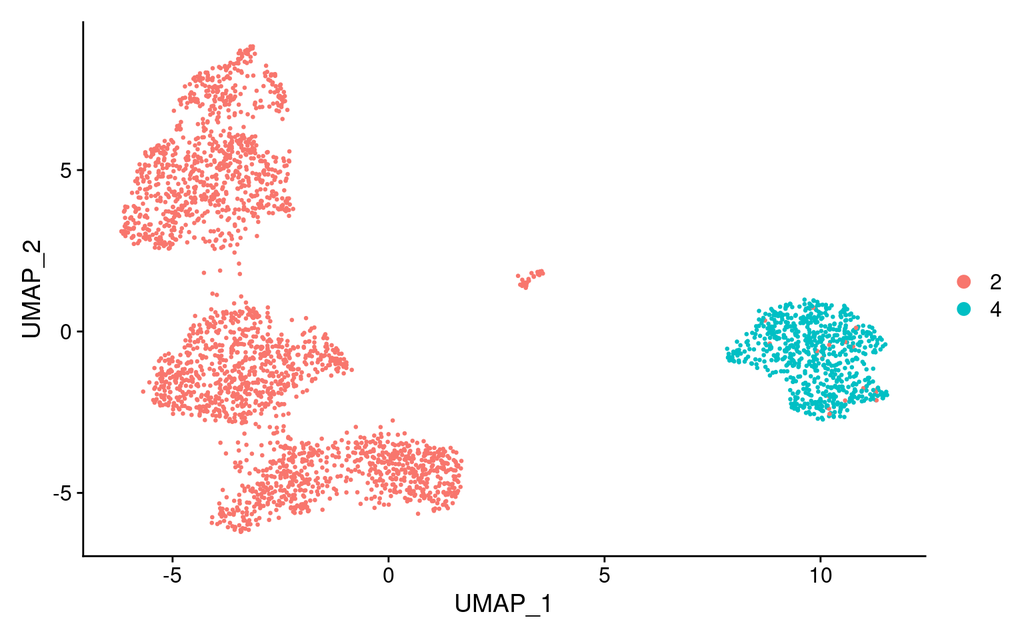

```r
query <- subset(query, idents = c("2", "4"))
query <- query %>%
  FindVariableFeatures() %>%
  ScaleData() %>%
  RunPCA() %>%
  RunUMAP(dims = 1:20, reduction = "pca")
DimPlot(query, reduction = "umap")
```

Cluster with low resolution:

```r
query <- FindNeighbors(query, reduction = "pca", dims = 1:20)
query <- FindClusters(query, resolution = 0.15)
```

```
## Modularity Optimizer version 1.3.0 by Ludo Waltman and Nees Jan van Eck
##
## Number of nodes: 3167
## Number of edges: 124627
##
## Running Louvain algorithm...
## Maximum modularity in 10 random starts: 0.9473
## Number of communities: 5
## Elapsed time: 0 seconds
```

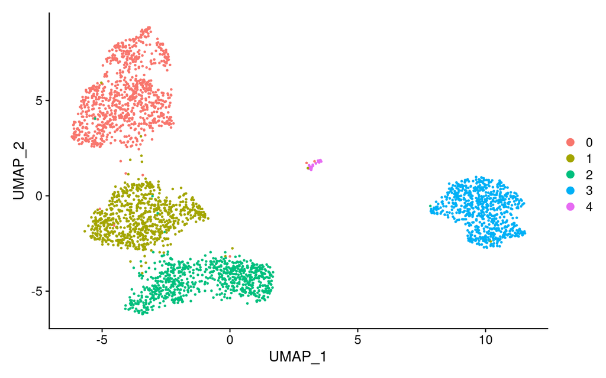

```r
DimPlot(query, reduction = "umap")
```

```r
# Find markers
markers_all <- FindAllMarkers(query, logfc.threshold = 0.5, only.pos = TRUE)
DT::datatable(markers_all)
```

|  | p_val | avg_log2FC | pct.1 | pct.2 | p_val_adj | cluster | gene |
| --- | --- | --- | --- | --- | --- | --- | --- |
| CCL5 | 0 | 3.12169412437268 | 0.779 | 0.123 | 0 | 0 | CCL5 |
| GZMK | 0 | 2.63235174518692 | 0.73 | 0.092 | 0 | 0 | GZMK |
| NKG7 | 2.64654829973672e-268 | 2.64027309781087 | 0.625 | 0.071 | 9.68663143186637e-264 | 0 | NKG7 |
| GZMA | 4.81832220552079e-219 | 2.21231850612074 | 0.567 | 0.078 | 1.76355411044266e-214 | 0 | GZMA |
| CST7 | 2.02380655316697e-209 | 2.12307532165618 | 0.663 | 0.169 | 7.40733436524644e-205 | 0 | CST7 |
| CRTAM | 1.06073700752134e-197 | 2.45307470901204 | 0.498 | 0.059 | 3.88240352122885e-193 | 0 | CRTAM |
| DTHD1 | 2.82682077945943e-163 | 2.04961574927341 | 0.464 | 0.071 | 1.03464467348994e-158 | 0 | DTHD1 |
| ENC1 | 6.96840787701602e-137 | 1.84424141915639 | 0.452 | 0.097 | 2.55050696706663e-132 | 0 | ENC1 |
| LYST | 2.46430219415272e-136 | 1.85110723897204 | 0.703 | 0.368 | 9.01959246081836e-132 | 0 | LYST |
| AOAH | 1.40081848330224e-123 | 2.00202806423491 | 0.607 | 0.254 | 5.12713573073452e-119 | 0 | AOAH |

[output cut: 1235 more lines]

- Cluster 0: cytotoxic cells (CD8 T and/or NK and/or ILC)
- Cluster 1: CD4 T cells
- Cluster 2: CD4 T cells 2 (probably a mix of effector and Treg, since they express PRDM1)
- Cluster 3: doublets with B cells
- Cluster 4: probably NK (GNLY, NCAM1)

Thus, we will conserve clusters 1 and 2

```r
query <- subset(query, idents = c("1", "2"))
```

Nevertheless, we know from other analysis that naive CD8 T cells cluster with naive CD4 T cells:

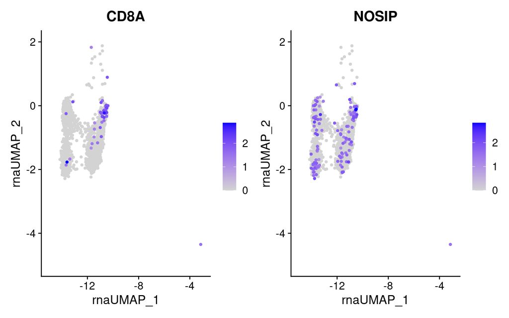

```r
FeaturePlot(query, c("CD8A", "NOSIP"), order = TRUE)
```

Thus, we subcluster cluster 1:

```r
query <- FindNeighbors(query, reduction = "pca", dims = 1:20)
query <- FindSubCluster(
  query,
  cluster = "1",
  subcluster.name = "naive_CD8",
  graph.name = "RNA_snn",
  resolution = 0.5
)
```

```
## Modularity Optimizer version 1.3.0 by Ludo Waltman and Nees Jan van Eck
##
## Number of nodes: 765
## Number of edges: 28806
##
## Running Louvain algorithm...
## Maximum modularity in 10 random starts: 0.6924
## Number of communities: 4
## Elapsed time: 0 seconds
```

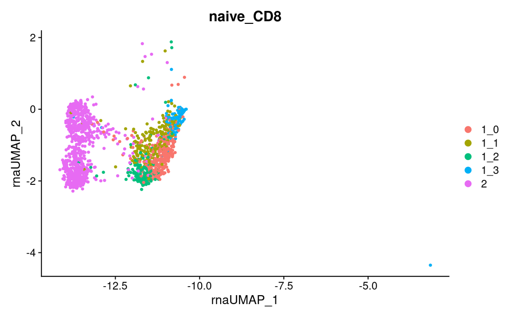

```r
DimPlot(query, group.by = "naive_CD8")
```

```r
Idents(query) <- "naive_CD8"
markers_1_3 <- FindMarkers(
  query,
  ident.1 = "1_3",
  only.pos = TRUE,
  logfc.threshold = 0.75
)
DT::datatable(markers_1_3)
```

|  | p_val | avg_log2FC | pct.1 | pct.2 | p_val_adj |
| --- | --- | --- | --- | --- | --- |
| CSGALNACT1 | 7.76893233923633e-47 | 1.60710819123842 | 0.585 | 0.095 | 2.84350692548389e-42 |
| KLRK1 | 1.12415397447958e-43 | 1.08788262043835 | 0.264 | 0.016 | 4.11451596199271e-39 |
| ANXA1 | 1.21318912939989e-39 | 1.7191279829397 | 0.802 | 0.24 | 4.44039353251652e-35 |
| CD8A | 2.54702861572431e-36 | 1.03438402653207 | 0.226 | 0.014 | 9.32237943641255e-32 |
| YBX3 | 1.25230487980687e-31 | 1.30613477772683 | 0.245 | 0.022 | 4.58356109058111e-27 |
| NELL2 | 9.04078271829995e-31 | 1.56844784078628 | 0.689 | 0.199 | 3.30901688272496e-26 |
| CD55 | 4.19901288807663e-24 | 1.33031129589339 | 0.774 | 0.321 | 1.53688070716493e-19 |
| SLC39A8 | 2.88120233169605e-23 | 1.02049443526092 | 0.472 | 0.116 | 1.05454886542407e-18 |
| SORL1 | 5.68501927611009e-22 | 1.26860721201451 | 0.538 | 0.162 | 2.08077390524905e-17 |
| SLCO3A1 | 1.60370709253165e-21 | 1.30631507396257 | 0.604 | 0.204 | 5.86972832937509e-17 |

[output cut: 50 more lines]

We can see how subcluster 1_3 belongs to cytotoxic cells. Let us exclude it:

```r
query <- subset(query, cells = colnames(query)[query$naive_CD8 != "1_3"])
```

## 3.2 Merge

We will merge both objects, keeping only the variables in the metadata that are common for both:

```r
# Define new variables for label transfer
reference$type <- "reference"
query$type <- "query"
reference$batch <- reference@meta.data[[batch_var]]
reference$label <- reference@meta.data[[label_var]]
reference$annotation_probability <- NA
reference$UMAP1 <- Embeddings(reference, "umap")[, "UMAP_1"]
reference$UMAP2 <- Embeddings(reference, "umap")[, "UMAP_2"]
query$label <- NA
query$annotation_probability <- NA
query$batch <- "query"
query$UMAP1 <- NA
query$UMAP2 <- NA


# Find common columns and subset
common_cols <- intersect(
  colnames(reference@meta.data),
  colnames(query@meta.data)
)
reference@meta.data <- reference@meta.data[, common_cols]
query@meta.data <- query@meta.data[, common_cols]
```

Now we can merge:

```r
merged <- merge(x = reference, y = query)
```

## 3.3 Integrate

Let us start by finding the batch-specific highly variable features (HVG):

```r
shared_features <- find_assay_specific_features(merged, assay_var = "batch")
```

Integrate with Harmony:

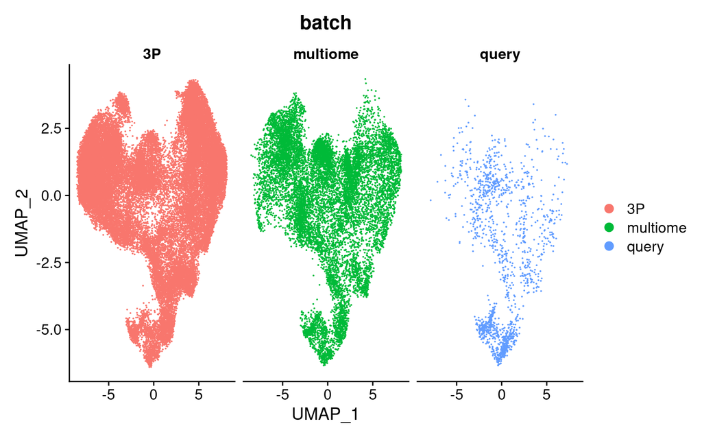

```r
# Integrate
merged <- integrate_assays(
  merged,
  assay_specific = TRUE,
  assay_var = "batch",
  shared_hvg = shared_features,
  n_dim = 30
)


# Visualize integration
merged <- RunUMAP(merged, dims = 1:30, reduction = "harmony")
DimPlot(merged, group.by = "batch", split.by = "batch")
```

## 3.4 Transfer labels

```r
# Define training and test sets
data_sets <- SLOcatoR::split_training_and_test_sets(
  merged,
  split_var = "type",
  referece_label = "reference",
  query_label = "query",
  reduction = "harmony",
  n_dims = 30
)


# Transfer label
annotation_query_df <- transfer_label(
  seurat_obj = merged,
  training_set = data_sets$training_set,
  test_set = data_sets$test_set,
  k = 10,
  response_var = "label"
)
```

## 3.5 Transfer UMAP coordinates

```r
umap_test_df <- transfer_umap_coords(
  seurat_obj = merged,
  training_set = data_sets$training_set,
  test_set = data_sets$test_set,
  umap1_var = "UMAP1",
  umap2_var = "UMAP2",
  k = 10
)
```

# 4 Plot

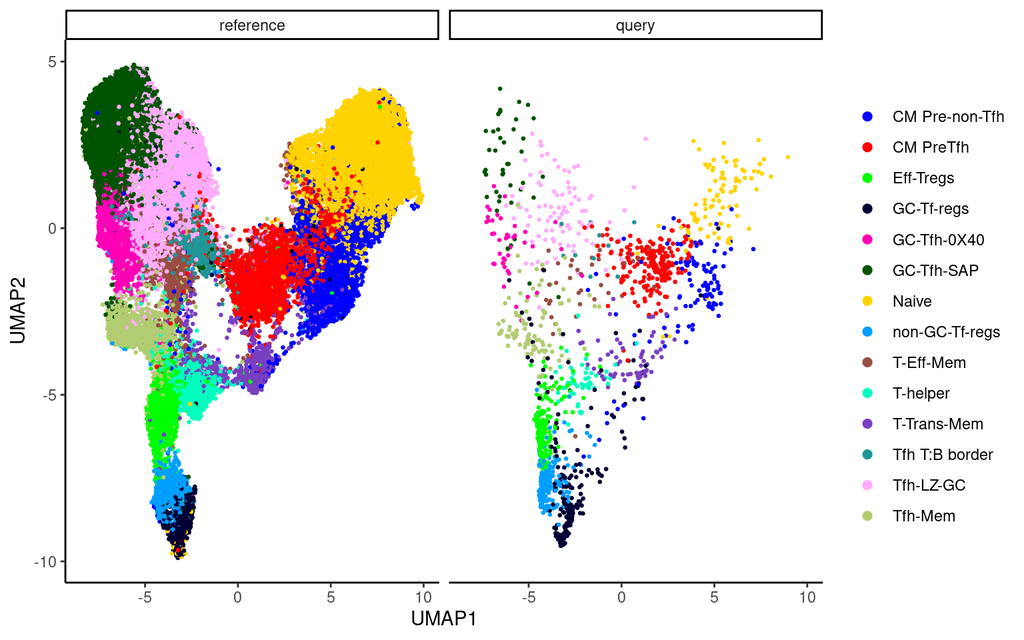

```r
merged$UMAP1[umap_test_df$query_cells] <- umap_test_df$UMAP1
merged$UMAP2[umap_test_df$query_cells] <- umap_test_df$UMAP2
merged$label[annotation_query_df$query_cells] <- annotation_query_df$annotation
merged$annotation_probability[annotation_query_df$query_cells] <- annotation_query_df$annotation_prob
(umap_gg <- merged@meta.data %>%
  mutate(type = factor(type, levels = c("reference", "query"))) %>%
  ggplot(aes(UMAP1, UMAP2, color = label)) +
    geom_point(size = 0.5) +
    facet_wrap(~type) +
    scale_color_manual(values = pals::glasbey()) +
    theme_classic() +
    theme(legend.title = element_blank()) +
    guides(color = guide_legend(override.aes = list(size = 2))))
```

Include annotations in query object:

```r
if (all(colnames(query) == annotation_query_df$query_cells)) {
  query$annotation_SLOcatoR <- annotation_query_df$annotation
  query$annotation_probability <- annotation_query_df$annotation_prob
}
if (all(colnames(query) == umap_test_df$query_cells)) {
  query$UMAP_1_SLOcatoR <- umap_test_df$UMAP1
  query$UMAP_2_SLOcatoR <- umap_test_df$UMAP2
}
query$label <- NULL
```

# 5 Save

```r
saveRDS(merged, path_to_save1)
saveRDS(query, path_to_save2)
# saveRDS(merged@meta.data, path_to_save_df)
```